# Part-1

## About the dataset

This is perhaps the best known database to be found in the pattern recognition literature. The data set contains 3 classes of 50 instances each, where each class refers to a type of iris plant. One class is linearly separable from the other 2; the latter are NOT linearly separable from each other.

Attribute Information:

1. sepal length in cm
2. sepal width in cm
3. petal length in cm
4. petal width in cm
5. class: -- Iris Setosa -- Iris Versicolour -- Iris Virginica

### Read the dataset and store it in the dataframe named Iris

```python
from pandas import read_csv
# read the data
import pandas as pd
import numpy as np
Iris = pd.read_csv("Iris_external.csv")
```

### Find out the datatypes of each and every column

```python
Iris.dtypes
```

```
Sepal Length (in cm)    float64
Sepal Width in (cm)     float64
Petal length (in cm)    float64
Petal width (in cm)     float64
Class                    object
dtype: object
```

### Print top 10 & bottom 10 samples from the dataframe

```python
print("Top 10 records are as follows:")
Iris.head(10)
```

```
Top 10 records are as follows:
```

|  | Sepal Length (in cm) | Sepal Width in (cm) | Petal length (in cm) | Petal width (in cm) | Class |
| --- | --- | --- | --- | --- | --- |
| 0 | 5.1 | 3.5 | 1.4 | 0.2 | Iris-setosa |
| 1 | 4.9 | 3.0 | 1.4 | 0.2 | Iris-setosa |
| 2 | 4.7 | 3.2 | 1.3 | 0.2 | Iris-setosa |
| 3 | 4.6 | 3.1 | 1.5 | 0.2 | Iris-setosa |
| 4 | 5.0 | 3.6 | 1.4 | 0.2 | Iris-setosa |
| 5 | 5.4 | 3.9 | 1.7 | 0.4 | Iris-setosa |
| 6 | 4.6 | 3.4 | 1.4 | 0.3 | Iris-setosa |
| 7 | 5.0 | 3.4 | 1.5 | 0.2 | Iris-setosa |
| 8 | 4.4 | 2.9 | 1.4 | 0.2 | Iris-setosa |
| 9 | 4.9 | 3.1 | 1.5 | 0.1 | Iris-setosa |

```python
print("Bottom 10 records are as follows:")
Iris.tail(10)
```

```
Bottom 10 records are as follows:
```

|  | Sepal Length (in cm) | Sepal Width in (cm) | Petal length (in cm) | Petal width (in cm) | Class |
| --- | --- | --- | --- | --- | --- |
| 140 | 6.7 | 3.1 | 5.6 | 2.4 | Iris-virginica |
| 141 | 6.9 | 3.1 | 5.1 | 2.3 | Iris-virginica |
| 142 | 5.8 | 2.7 | 5.1 | 1.9 | Iris-virginica |
| 143 | 6.8 | 3.2 | 5.9 | 2.3 | Iris-virginica |
| 144 | 6.7 | 3.3 | 5.7 | 2.5 | Iris-virginica |
| 145 | 6.7 | 3.0 | 5.2 | 2.3 | Iris-virginica |
| 146 | 6.3 | 2.5 | 5.0 | 1.9 | Iris-virginica |
| 147 | 6.5 | 3.0 | 5.2 | 2.0 | Iris-virginica |
| 148 | 6.2 | 3.4 | 5.4 | 2.3 | Iris-virginica |
| 149 | 5.9 | 3.0 | 5.1 | 1.8 | Iris-virginica |

### Find the shape of the dataset

```python
print("The shape of the dataset is as follows:")
Iris.shape
```

```
The shape of the dataset is as follows:
```

```
(150, 5)
```

### Set the index of the dataframe to be the first column

```python
Iris.reset_index(level=0,inplace=True)
Iris.set_index('index',inplace=True)
```

```python
Iris.head()
```

| index | Sepal Length (in cm) | Sepal Width in (cm) | Petal length (in cm) | Petal width (in cm) | Class |
| --- | --- | --- | --- | --- | --- |
| 0 | 5.1 | 3.5 | 1.4 | 0.2 | Iris-setosa |
| 1 | 4.9 | 3.0 | 1.4 | 0.2 | Iris-setosa |
| 2 | 4.7 | 3.2 | 1.3 | 0.2 | Iris-setosa |
| 3 | 4.6 | 3.1 | 1.5 | 0.2 | Iris-setosa |
| 4 | 5.0 | 3.6 | 1.4 | 0.2 | Iris-setosa |

### Use iloc function to print all the rows of the 3rd column

```python
Iris.iloc[:,2]
```

```
index
0      1.4
1      1.4
2      1.3
3      1.5
4      1.4
5      1.7
6      1.4
7      1.5
8      1.4
9      1.5
10     1.5
11     1.6
12     1.4
13     1.1
```

[output cut: 48 more lines]

### Slicing

Print only the Sepal width and Sepal Length for first 10 rows

```python
print("Sepal width and Sepal Length of first 10 rows is as follows:")
Iris.loc[:,['Sepal Width in (cm)','Sepal Length (in cm)']].head(10)
```

```
Sepal width and Sepal Length of first 10 rows is as follows:
```

| index | Sepal Width in (cm) | Sepal Length (in cm) |
| --- | --- | --- |
| 0 | 3.5 | 5.1 |
| 1 | 3.0 | 4.9 |
| 2 | 3.2 | 4.7 |
| 3 | 3.1 | 4.6 |
| 4 | 3.6 | 5.0 |
| 5 | 3.9 | 5.4 |
| 6 | 3.4 | 4.6 |
| 7 | 3.4 | 5.0 |
| 8 | 2.9 | 4.4 |
| 9 | 3.1 | 4.9 |

### Using Logical statements for indexing

Print all the columns of row which has class name "Iris-setosa"

```python
Iris.loc[Iris['Class']=='Iris-setosa']
```

| index | Sepal Length (in cm) | Sepal Width in (cm) | Petal length (in cm) | Petal width (in cm) | Class |
| --- | --- | --- | --- | --- | --- |
| 0 | 5.1 | 3.5 | 1.4 | 0.2 | Iris-setosa |
| 1 | 4.9 | 3.0 | 1.4 | 0.2 | Iris-setosa |
| 2 | 4.7 | 3.2 | 1.3 | 0.2 | Iris-setosa |
| 3 | 4.6 | 3.1 | 1.5 | 0.2 | Iris-setosa |
| 4 | 5.0 | 3.6 | 1.4 | 0.2 | Iris-setosa |
| 5 | 5.4 | 3.9 | 1.7 | 0.4 | Iris-setosa |
| 6 | 4.6 | 3.4 | 1.4 | 0.3 | Iris-setosa |
| 7 | 5.0 | 3.4 | 1.5 | 0.2 | Iris-setosa |
| 8 | 4.4 | 2.9 | 1.4 | 0.2 | Iris-setosa |
| 9 | 4.9 | 3.1 | 1.5 | 0.1 | Iris-setosa |
| 10 | 5.4 | 3.7 | 1.5 | 0.2 | Iris-setosa |
| 11 | 4.8 | 3.4 | 1.6 | 0.2 | Iris-setosa |
| 12 | 4.8 | 3.0 | 1.4 | 0.1 | Iris-setosa |
| 13 | 4.3 | 3.0 | 1.1 | 0.1 | Iris-setosa |
| 14 | 5.8 | 4.0 | 1.2 | 0.2 | Iris-setosa |
| 15 | 5.7 | 4.4 | 1.5 | 0.4 | Iris-setosa |
| 16 | 5.4 | 3.9 | 1.3 | 0.4 | Iris-setosa |
| 17 | 5.1 | 3.5 | 1.4 | 0.3 | Iris-setosa |
| 18 | 5.7 | 3.8 | 1.7 | 0.3 | Iris-setosa |
| 19 | 5.1 | 3.8 | 1.5 | 0.3 | Iris-setosa |
| 20 | 5.4 | 3.4 | 1.7 | 0.2 | Iris-setosa |
| 21 | 5.1 | 3.7 | 1.5 | 0.4 | Iris-setosa |
| 22 | 4.6 | 3.6 | 1.0 | 0.2 | Iris-setosa |
| 23 | 5.1 | 3.3 | 1.7 | 0.5 | Iris-setosa |
| 24 | 4.8 | 3.4 | 1.9 | 0.2 | Iris-setosa |
| 25 | 5.0 | 3.0 | 1.6 | 0.2 | Iris-setosa |
| 26 | 5.0 | 3.4 | 1.6 | 0.4 | Iris-setosa |
| 27 | 5.2 | 3.5 | 1.5 | 0.2 | Iris-setosa |
| 28 | 5.2 | 3.4 | 1.4 | 0.2 | Iris-setosa |
| 29 | 4.7 | 3.2 | 1.6 | 0.2 | Iris-setosa |
| 30 | 4.8 | 3.1 | 1.6 | 0.2 | Iris-setosa |
| 31 | 5.4 | 3.4 | 1.5 | 0.4 | Iris-setosa |
| 32 | 5.2 | 4.1 | 1.5 | 0.1 | Iris-setosa |
| 33 | 5.5 | 4.2 | 1.4 | 0.2 | Iris-setosa |
| 34 | 4.9 | 3.1 | 1.5 | 0.1 | Iris-setosa |
| 35 | 5.0 | 3.2 | 1.2 | 0.2 | Iris-setosa |
| 36 | 5.5 | 3.5 | 1.3 | 0.2 | Iris-setosa |
| 37 | 4.9 | 3.1 | 1.5 | 0.1 | Iris-setosa |
| 38 | 4.4 | 3.0 | 1.3 | 0.2 | Iris-setosa |
| 39 | 5.1 | 3.4 | 1.5 | 0.2 | Iris-setosa |
| 40 | 5.0 | 3.5 | 1.3 | 0.3 | Iris-setosa |
| 41 | 4.5 | 2.3 | 1.3 | 0.3 | Iris-setosa |
| 42 | 4.4 | 3.2 | 1.3 | 0.2 | Iris-setosa |
| 43 | 5.0 | 3.5 | 1.6 | 0.6 | Iris-setosa |
| 44 | 5.1 | 3.8 | 1.9 | 0.4 | Iris-setosa |
| 45 | 4.8 | 3.0 | 1.4 | 0.3 | Iris-setosa |
| 46 | 5.1 | 3.8 | 1.6 | 0.2 | Iris-setosa |
| 47 | 4.6 | 3.2 | 1.4 | 0.2 | Iris-setosa |
| 48 | 5.3 | 3.7 | 1.5 | 0.2 | Iris-setosa |
| 49 | 5.0 | 3.3 | 1.4 | 0.2 | Iris-setosa |

### Multiply Sepal Length and width and store it under the column name "SepalExtra" in the same Iris dataframe

```python
Iris['SepalExtra (in cm)']=Iris['Sepal Length (in cm)']*Iris['Sepal Width in (cm)']
```

```python
Iris
```

| index | Sepal Length (in cm) | Sepal Width in (cm) | Petal length (in cm) | Petal width (in cm) | Class | SepalExtra (in cm) |
| --- | --- | --- | --- | --- | --- | --- |
| 0 | 5.1 | 3.5 | 1.4 | 0.2 | Iris-setosa | 17.85 |
| 1 | 4.9 | 3.0 | 1.4 | 0.2 | Iris-setosa | 14.70 |
| 2 | 4.7 | 3.2 | 1.3 | 0.2 | Iris-setosa | 15.04 |
| 3 | 4.6 | 3.1 | 1.5 | 0.2 | Iris-setosa | 14.26 |
| 4 | 5.0 | 3.6 | 1.4 | 0.2 | Iris-setosa | 18.00 |
| 5 | 5.4 | 3.9 | 1.7 | 0.4 | Iris-setosa | 21.06 |
| 6 | 4.6 | 3.4 | 1.4 | 0.3 | Iris-setosa | 15.64 |
| 7 | 5.0 | 3.4 | 1.5 | 0.2 | Iris-setosa | 17.00 |
| 8 | 4.4 | 2.9 | 1.4 | 0.2 | Iris-setosa | 12.76 |
| 9 | 4.9 | 3.1 | 1.5 | 0.1 | Iris-setosa | 15.19 |
| 10 | 5.4 | 3.7 | 1.5 | 0.2 | Iris-setosa | 19.98 |
| 11 | 4.8 | 3.4 | 1.6 | 0.2 | Iris-setosa | 16.32 |
| 12 | 4.8 | 3.0 | 1.4 | 0.1 | Iris-setosa | 14.40 |
| 13 | 4.3 | 3.0 | 1.1 | 0.1 | Iris-setosa | 12.90 |
| 14 | 5.8 | 4.0 | 1.2 | 0.2 | Iris-setosa | 23.20 |
| 15 | 5.7 | 4.4 | 1.5 | 0.4 | Iris-setosa | 25.08 |
| 16 | 5.4 | 3.9 | 1.3 | 0.4 | Iris-setosa | 21.06 |
| 17 | 5.1 | 3.5 | 1.4 | 0.3 | Iris-setosa | 17.85 |
| 18 | 5.7 | 3.8 | 1.7 | 0.3 | Iris-setosa | 21.66 |
| 19 | 5.1 | 3.8 | 1.5 | 0.3 | Iris-setosa | 19.38 |
| 20 | 5.4 | 3.4 | 1.7 | 0.2 | Iris-setosa | 18.36 |
| 21 | 5.1 | 3.7 | 1.5 | 0.4 | Iris-setosa | 18.87 |
| 22 | 4.6 | 3.6 | 1.0 | 0.2 | Iris-setosa | 16.56 |
| 23 | 5.1 | 3.3 | 1.7 | 0.5 | Iris-setosa | 16.83 |
| 24 | 4.8 | 3.4 | 1.9 | 0.2 | Iris-setosa | 16.32 |
| 25 | 5.0 | 3.0 | 1.6 | 0.2 | Iris-setosa | 15.00 |
| 26 | 5.0 | 3.4 | 1.6 | 0.4 | Iris-setosa | 17.00 |
| 27 | 5.2 | 3.5 | 1.5 | 0.2 | Iris-setosa | 18.20 |
| 28 | 5.2 | 3.4 | 1.4 | 0.2 | Iris-setosa | 17.68 |
| 29 | 4.7 | 3.2 | 1.6 | 0.2 | Iris-setosa | 15.04 |
| ... | ... | ... | ... | ... | ... | ... |
| 120 | 6.9 | 3.2 | 5.7 | 2.3 | Iris-virginica | 22.08 |
| 121 | 5.6 | 2.8 | 4.9 | 2.0 | Iris-virginica | 15.68 |
| 122 | 7.7 | 2.8 | 6.7 | 2.0 | Iris-virginica | 21.56 |
| 123 | 6.3 | 2.7 | 4.9 | 1.8 | Iris-virginica | 17.01 |
| 124 | 6.7 | 3.3 | 5.7 | 2.1 | Iris-virginica | 22.11 |
| 125 | 7.2 | 3.2 | 6.0 | 1.8 | Iris-virginica | 23.04 |
| 126 | 6.2 | 2.8 | 4.8 | 1.8 | Iris-virginica | 17.36 |
| 127 | 6.1 | 3.0 | 4.9 | 1.8 | Iris-virginica | 18.30 |
| 128 | 6.4 | 2.8 | 5.6 | 2.1 | Iris-virginica | 17.92 |
| 129 | 7.2 | 3.0 | 5.8 | 1.6 | Iris-virginica | 21.60 |
| 130 | 7.4 | 2.8 | 6.1 | 1.9 | Iris-virginica | 20.72 |
| 131 | 7.9 | 3.8 | 6.4 | 2.0 | Iris-virginica | 30.02 |
| 132 | 6.4 | 2.8 | 5.6 | 2.2 | Iris-virginica | 17.92 |
| 133 | 6.3 | 2.8 | 5.1 | 1.5 | Iris-virginica | 17.64 |
| 134 | 6.1 | 2.6 | 5.6 | 1.4 | Iris-virginica | 15.86 |
| 135 | 7.7 | 3.0 | 6.1 | 2.3 | Iris-virginica | 23.10 |
| 136 | 6.3 | 3.4 | 5.6 | 2.4 | Iris-virginica | 21.42 |
| 137 | 6.4 | 3.1 | 5.5 | 1.8 | Iris-virginica | 19.84 |
| 138 | 6.0 | 3.0 | 4.8 | 1.8 | Iris-virginica | 18.00 |
| 139 | 6.9 | 3.1 | 5.4 | 2.1 | Iris-virginica | 21.39 |
| 140 | 6.7 | 3.1 | 5.6 | 2.4 | Iris-virginica | 20.77 |
| 141 | 6.9 | 3.1 | 5.1 | 2.3 | Iris-virginica | 21.39 |
| 142 | 5.8 | 2.7 | 5.1 | 1.9 | Iris-virginica | 15.66 |
| 143 | 6.8 | 3.2 | 5.9 | 2.3 | Iris-virginica | 21.76 |
| 144 | 6.7 | 3.3 | 5.7 | 2.5 | Iris-virginica | 22.11 |
| 145 | 6.7 | 3.0 | 5.2 | 2.3 | Iris-virginica | 20.10 |
| 146 | 6.3 | 2.5 | 5.0 | 1.9 | Iris-virginica | 15.75 |
| 147 | 6.5 | 3.0 | 5.2 | 2.0 | Iris-virginica | 19.50 |
| 148 | 6.2 | 3.4 | 5.4 | 2.3 | Iris-virginica | 21.08 |
| 149 | 5.9 | 3.0 | 5.1 | 1.8 | Iris-virginica | 17.70 |

150 rows × 6 columns

### Find out the mean and variance for each column but for class column

```python
Iris.groupby('Class').agg(["mean","var"])
```

| Class | Sepal Length (in cm) mean | Sepal Length (in cm) var | Sepal Width in (cm) mean | Sepal Width in (cm) var | Petal length (in cm) mean | Petal length (in cm) var | Petal width (in cm) mean | Petal width (in cm) var | SepalExtra (in cm) mean | SepalExtra (in cm) var |
| --- | --- | --- | --- | --- | --- | --- | --- | --- | --- | --- |
| Iris-setosa | 5.006 | 0.124249 | 3.418 | 0.145180 | 1.464 | 0.030106 | 0.244 | 0.011494 | 17.2088 | 8.688864 |
| Iris-versicolor | 5.936 | 0.266433 | 2.770 | 0.098469 | 4.260 | 0.220816 | 1.326 | 0.039106 | 16.5262 | 8.219012 |
| Iris-virginica | 6.588 | 0.404343 | 2.974 | 0.104004 | 5.552 | 0.304588 | 2.026 | 0.075433 | 19.6846 | 11.963180 |

### Write a function that accepts two numbers as input and prints them - Pass the Sepal length and sepal width of 5th row and print the output

```python
def printf(a,b):
    print(a,b)
printf(Iris.loc[4,'Sepal Length (in cm)'],Iris.loc[4,'Sepal Width in (cm)'])
```

```
5.0 3.6
```

### Find the range of all the columns in the dataset

*Range = Max value - Min value (in the column)*

```python
#For numeric data types, the range is directly calculated from max-min value
u = Iris.select_dtypes(include=[np.number])
U = u.max() - u.min()
#For object type records, as we cannot perform string subtraction,
#I have concatenated the '-' value to the max and min string vaues
v = Iris.select_dtypes(include=[object])
V = v.max() + ' - ' + v.min()

U.append(V)
```

```
Sepal Length (in cm)                             3.6
Sepal Width in (cm)                              2.4
Petal length (in cm)                             5.9
Petal width (in cm)                              2.4
SepalExtra (in cm)                             20.02
Class                   Iris-virginica - Iris-setosa
dtype: object
```

### Sort the entire dataset according to the column Petal width

```python
Iris.sort_values(by='Petal width (in cm)')
```

| index | Sepal Length (in cm) | Sepal Width in (cm) | Petal length (in cm) | Petal width (in cm) | Class | SepalExtra (in cm) |
| --- | --- | --- | --- | --- | --- | --- |
| 32 | 5.2 | 4.1 | 1.5 | 0.1 | Iris-setosa | 21.32 |
| 13 | 4.3 | 3.0 | 1.1 | 0.1 | Iris-setosa | 12.90 |
| 37 | 4.9 | 3.1 | 1.5 | 0.1 | Iris-setosa | 15.19 |
| 9 | 4.9 | 3.1 | 1.5 | 0.1 | Iris-setosa | 15.19 |
| 12 | 4.8 | 3.0 | 1.4 | 0.1 | Iris-setosa | 14.40 |
| 34 | 4.9 | 3.1 | 1.5 | 0.1 | Iris-setosa | 15.19 |
| 0 | 5.1 | 3.5 | 1.4 | 0.2 | Iris-setosa | 17.85 |
| 27 | 5.2 | 3.5 | 1.5 | 0.2 | Iris-setosa | 18.20 |
| 28 | 5.2 | 3.4 | 1.4 | 0.2 | Iris-setosa | 17.68 |
| 29 | 4.7 | 3.2 | 1.6 | 0.2 | Iris-setosa | 15.04 |
| 30 | 4.8 | 3.1 | 1.6 | 0.2 | Iris-setosa | 14.88 |
| 33 | 5.5 | 4.2 | 1.4 | 0.2 | Iris-setosa | 23.10 |
| 36 | 5.5 | 3.5 | 1.3 | 0.2 | Iris-setosa | 19.25 |
| 38 | 4.4 | 3.0 | 1.3 | 0.2 | Iris-setosa | 13.20 |
| 39 | 5.1 | 3.4 | 1.5 | 0.2 | Iris-setosa | 17.34 |
| 42 | 4.4 | 3.2 | 1.3 | 0.2 | Iris-setosa | 14.08 |
| 46 | 5.1 | 3.8 | 1.6 | 0.2 | Iris-setosa | 19.38 |
| 47 | 4.6 | 3.2 | 1.4 | 0.2 | Iris-setosa | 14.72 |
| 48 | 5.3 | 3.7 | 1.5 | 0.2 | Iris-setosa | 19.61 |
| 49 | 5.0 | 3.3 | 1.4 | 0.2 | Iris-setosa | 16.50 |
| 25 | 5.0 | 3.0 | 1.6 | 0.2 | Iris-setosa | 15.00 |
| 24 | 4.8 | 3.4 | 1.9 | 0.2 | Iris-setosa | 16.32 |
| 35 | 5.0 | 3.2 | 1.2 | 0.2 | Iris-setosa | 16.00 |
| 3 | 4.6 | 3.1 | 1.5 | 0.2 | Iris-setosa | 14.26 |
| 2 | 4.7 | 3.2 | 1.3 | 0.2 | Iris-setosa | 15.04 |
| 7 | 5.0 | 3.4 | 1.5 | 0.2 | Iris-setosa | 17.00 |
| 8 | 4.4 | 2.9 | 1.4 | 0.2 | Iris-setosa | 12.76 |
| 10 | 5.4 | 3.7 | 1.5 | 0.2 | Iris-setosa | 19.98 |
| 4 | 5.0 | 3.6 | 1.4 | 0.2 | Iris-setosa | 18.00 |
| 11 | 4.8 | 3.4 | 1.6 | 0.2 | Iris-setosa | 16.32 |
| ... | ... | ... | ... | ... | ... | ... |
| 111 | 6.4 | 2.7 | 5.3 | 1.9 | Iris-virginica | 17.28 |
| 121 | 5.6 | 2.8 | 4.9 | 2.0 | Iris-virginica | 15.68 |
| 122 | 7.7 | 2.8 | 6.7 | 2.0 | Iris-virginica | 21.56 |
| 147 | 6.5 | 3.0 | 5.2 | 2.0 | Iris-virginica | 19.50 |
| 113 | 5.7 | 2.5 | 5.0 | 2.0 | Iris-virginica | 14.25 |
| 131 | 7.9 | 3.8 | 6.4 | 2.0 | Iris-virginica | 30.02 |
| 110 | 6.5 | 3.2 | 5.1 | 2.0 | Iris-virginica | 20.80 |
| 139 | 6.9 | 3.1 | 5.4 | 2.1 | Iris-virginica | 21.39 |
| 102 | 7.1 | 3.0 | 5.9 | 2.1 | Iris-virginica | 21.30 |
| 112 | 6.8 | 3.0 | 5.5 | 2.1 | Iris-virginica | 20.40 |
| 105 | 7.6 | 3.0 | 6.6 | 2.1 | Iris-virginica | 22.80 |
| 124 | 6.7 | 3.3 | 5.7 | 2.1 | Iris-virginica | 22.11 |
| 128 | 6.4 | 2.8 | 5.6 | 2.1 | Iris-virginica | 17.92 |
| 117 | 7.7 | 3.8 | 6.7 | 2.2 | Iris-virginica | 29.26 |
| 132 | 6.4 | 2.8 | 5.6 | 2.2 | Iris-virginica | 17.92 |
| 104 | 6.5 | 3.0 | 5.8 | 2.2 | Iris-virginica | 19.50 |
| 120 | 6.9 | 3.2 | 5.7 | 2.3 | Iris-virginica | 22.08 |
| 115 | 6.4 | 3.2 | 5.3 | 2.3 | Iris-virginica | 20.48 |
| 148 | 6.2 | 3.4 | 5.4 | 2.3 | Iris-virginica | 21.08 |
| 141 | 6.9 | 3.1 | 5.1 | 2.3 | Iris-virginica | 21.39 |
| 143 | 6.8 | 3.2 | 5.9 | 2.3 | Iris-virginica | 21.76 |
| 145 | 6.7 | 3.0 | 5.2 | 2.3 | Iris-virginica | 20.10 |
| 118 | 7.7 | 2.6 | 6.9 | 2.3 | Iris-virginica | 20.02 |
| 135 | 7.7 | 3.0 | 6.1 | 2.3 | Iris-virginica | 23.10 |
| 136 | 6.3 | 3.4 | 5.6 | 2.4 | Iris-virginica | 21.42 |
| 140 | 6.7 | 3.1 | 5.6 | 2.4 | Iris-virginica | 20.77 |
| 114 | 5.8 | 2.8 | 5.1 | 2.4 | Iris-virginica | 16.24 |
| 100 | 6.3 | 3.3 | 6.0 | 2.5 | Iris-virginica | 20.79 |
| 144 | 6.7 | 3.3 | 5.7 | 2.5 | Iris-virginica | 22.11 |
| 109 | 7.2 | 3.6 | 6.1 | 2.5 | Iris-virginica | 25.92 |

150 rows × 6 columns

### Remove the new column "SepalExtra" from the dataframe

```python
Iris.drop(['SepalExtra (in cm)'],axis=1,inplace=True)
```

### Take only the top 10 rows of the dataset with only first 3 columns and store it in a dataframe named "IrisSubset"

```python
IrisSubset = Iris.iloc[0:10,0:3]
```

```python
IrisSubset
```

| index | Sepal Length (in cm) | Sepal Width in (cm) | Petal length (in cm) |
| --- | --- | --- | --- |
| 0 | 5.1 | 3.5 | 1.4 |
| 1 | 4.9 | 3.0 | 1.4 |
| 2 | 4.7 | 3.2 | 1.3 |
| 3 | 4.6 | 3.1 | 1.5 |
| 4 | 5.0 | 3.6 | 1.4 |
| 5 | 5.4 | 3.9 | 1.7 |
| 6 | 4.6 | 3.4 | 1.4 |
| 7 | 5.0 | 3.4 | 1.5 |
| 8 | 4.4 | 2.9 | 1.4 |
| 9 | 4.9 | 3.1 | 1.5 |

# Part-2

## The dataset HR contains information collected from the survey floated by a HR within the company.

As a part of this lab, you are expected to answer the below questions

### Import numpy and Pandas

```python
import numpy as np
import pandas as pd
```

### Import the dataset (Note: The dataset is in .txt format) - Make sure to use delimiters

```python
dataset=pd.read_csv("HR_external.txt",delimiter="\t")
dataset
```

|  | Individual | Attrition | Age | BusinessTravel | DailyRate | Department | DistanceFromHome | Education | EducationField | EmployeeCount | ... | RelationshipSatisfaction | StandardHours | StockOptionLevel | TotalWorkingYears | TrainingTimesLastYear | WorkLifeBalance | YearsAtCompany | YearsInCurrentRole | YearsSinceLastPromotion | YearsWithCurrManager |
| --- | --- | --- | --- | --- | --- | --- | --- | --- | --- | --- | --- | --- | --- | --- | --- | --- | --- | --- | --- | --- | --- |
| 0 | Ind1 | Yes | 41 | 1 | 1102 | 1 | 1 | 2 | 1 | 1 | ... | 1 | 80 | 0 | 8 | 0 | 1 | 6 | 4 | 0 | 5 |
| 1 | Ind2 | No | 49 | 2 | 279 | 2 | 8 | 1 | 1 | 1 | ... | 4 | 80 | 1 | 10 | 3 | 3 | 10 | 7 | 1 | 7 |
| 2 | Ind3 | Yes | 37 | 1 | 1373 | 2 | 2 | 2 | 6 | 1 | ... | 2 | 80 | 0 | 7 | 3 | 3 | 0 | 0 | 0 | 0 |
| 3 | Ind4 | No | 33 | 2 | 1392 | 2 | 3 | 4 | 1 | 1 | ... | 3 | 80 | 0 | 8 | 3 | 3 | 8 | 7 | 3 | 0 |
| 4 | Ind5 | No | 27 | 1 | 591 | 2 | 2 | 1 | 2 | 1 | ... | 4 | 80 | 1 | 6 | 3 | 3 | 2 | 2 | 2 | 2 |
| 5 | Ind6 | No | 32 | 2 | 1005 | 2 | 2 | 2 | 1 | 1 | ... | 3 | 80 | 0 | 8 | 2 | 2 | 7 | 7 | 3 | 6 |
| 6 | Ind7 | No | 59 | 1 | 1324 | 2 | 3 | 3 | 2 | 1 | ... | 1 | 80 | 3 | 12 | 3 | 2 | 1 | 0 | 0 | 0 |
| 7 | Ind8 | No | 30 | 1 | 1358 | 2 | 24 | 1 | 1 | 1 | ... | 2 | 80 | 1 | 1 | 2 | 3 | 1 | 0 | 0 | 0 |
| 8 | Ind9 | No | 38 | 2 | 216 | 2 | 23 | 3 | 1 | 1 | ... | 2 | 80 | 0 | 10 | 2 | 3 | 9 | 7 | 1 | 8 |
| 9 | Ind10 | No | 36 | 1 | 1299 | 2 | 27 | 3 | 2 | 1 | ... | 2 | 80 | 2 | 17 | 3 | 2 | 7 | 7 | 7 | 7 |
| 10 | Ind11 | No | 35 | 1 | 809 | 2 | 16 | 3 | 2 | 1 | ... | 3 | 80 | 1 | 6 | 5 | 3 | 5 | 4 | 0 | 3 |
| 11 | Ind12 | No | 29 | 1 | 153 | 2 | 15 | 2 | 1 | 1 | ... | 4 | 80 | 0 | 10 | 3 | 3 | 9 | 5 | 0 | 8 |
| 12 | Ind13 | No | 31 | 1 | 670 | 2 | 26 | 1 | 1 | 1 | ... | 4 | 80 | 1 | 5 | 1 | 2 | 5 | 2 | 4 | 3 |
| 13 | Ind14 | No | 34 | 1 | 1346 | 2 | 19 | 2 | 2 | 1 | ... | 3 | 80 | 1 | 3 | 2 | 3 | 2 | 2 | 1 | 2 |
| 14 | Ind15 | Yes | 28 | 1 | 103 | 2 | 24 | 3 | 1 | 1 | ... | 2 | 80 | 0 | 6 | 4 | 3 | 4 | 2 | 0 | 3 |
| 15 | Ind16 | No | 29 | 1 | 1389 | 2 | 21 | 4 | 1 | 1 | ... | 3 | 80 | 1 | 10 | 1 | 3 | 10 | 9 | 8 | 8 |
| 16 | Ind17 | No | 32 | 1 | 334 | 2 | 5 | 2 | 1 | 1 | ... | 4 | 80 | 2 | 7 | 5 | 2 | 6 | 2 | 0 | 5 |
| 17 | Ind18 | No | 22 | 3 | 1123 | 2 | 16 | 2 | 2 | 1 | ... | 2 | 80 | 2 | 1 | 2 | 2 | 1 | 0 | 0 | 0 |
| 18 | Ind19 | No | 53 | 1 | 1219 | 1 | 2 | 4 | 1 | 1 | ... | 3 | 80 | 0 | 31 | 3 | 3 | 25 | 8 | 3 | 7 |
| 19 | Ind20 | No | 38 | 1 | 371 | 2 | 2 | 3 | 1 | 1 | ... | 3 | 80 | 0 | 6 | 3 | 3 | 3 | 2 | 1 | 2 |
| 20 | Ind21 | No | 24 | 3 | 673 | 2 | 11 | 2 | 6 | 1 | ... | 4 | 80 | 1 | 5 | 5 | 2 | 4 | 2 | 1 | 3 |
| 21 | Ind22 | Yes | 36 | 1 | 1218 | 1 | 9 | 4 | 1 | 1 | ... | 2 | 80 | 0 | 10 | 4 | 3 | 5 | 3 | 0 | 3 |
| 22 | Ind23 | No | 34 | 1 | 419 | 2 | 7 | 4 | 1 | 1 | ... | 3 | 80 | 0 | 13 | 4 | 3 | 12 | 6 | 2 | 11 |
| 23 | Ind24 | No | 21 | 1 | 391 | 2 | 15 | 2 | 1 | 1 | ... | 4 | 80 | 0 | 0 | 6 | 3 | 0 | 0 | 0 | 0 |
| 24 | Ind25 | Yes | 34 | 1 | 699 | 2 | 6 | 1 | 2 | 1 | ... | 3 | 80 | 0 | 8 | 2 | 3 | 4 | 2 | 1 | 3 |
| 25 | Ind26 | No | 53 | 1 | 1282 | 2 | 5 | 3 | 6 | 1 | ... | 4 | 80 | 1 | 26 | 3 | 2 | 14 | 13 | 4 | 8 |
| 26 | Ind27 | Yes | 32 | 2 | 1125 | 2 | 16 | 1 | 1 | 1 | ... | 2 | 80 | 0 | 10 | 5 | 3 | 10 | 2 | 6 | 7 |
| 27 | Ind28 | No | 42 | 1 | 691 | 1 | 8 | 4 | 3 | 1 | ... | 4 | 80 | 1 | 10 | 2 | 3 | 9 | 7 | 4 | 2 |
| 28 | Ind29 | No | 44 | 1 | 477 | 2 | 7 | 4 | 2 | 1 | ... | 4 | 80 | 1 | 24 | 4 | 3 | 22 | 6 | 5 | 17 |
| 29 | Ind30 | No | 46 | 1 | 705 | 1 | 2 | 4 | 3 | 1 | ... | 4 | 80 | 0 | 22 | 2 | 2 | 2 | 2 | 2 | 1 |
| ... | ... | ... | ... | ... | ... | ... | ... | ... | ... | ... | ... | ... | ... | ... | ... | ... | ... | ... | ... | ... | ... |
| 1440 | Ind1441 | No | 36 | 2 | 688 | 2 | 4 | 2 | 1 | 1 | ... | 2 | 80 | 3 | 18 | 3 | 3 | 4 | 2 | 0 | 2 |
| 1441 | Ind1442 | No | 56 | 3 | 667 | 2 | 1 | 4 | 1 | 1 | ... | 1 | 80 | 1 | 13 | 2 | 2 | 13 | 12 | 1 | 9 |
| 1442 | Ind1443 | Yes | 29 | 1 | 1092 | 2 | 1 | 4 | 2 | 1 | ... | 2 | 80 | 3 | 4 | 3 | 4 | 2 | 2 | 2 | 2 |
| 1443 | Ind1444 | No | 42 | 1 | 300 | 2 | 2 | 3 | 1 | 1 | ... | 1 | 80 | 0 | 24 | 2 | 2 | 22 | 6 | 4 | 14 |
| 1444 | Ind1445 | Yes | 56 | 1 | 310 | 2 | 7 | 2 | 4 | 1 | ... | 4 | 80 | 1 | 14 | 4 | 1 | 10 | 9 | 9 | 8 |
| 1445 | Ind1446 | No | 41 | 1 | 582 | 2 | 28 | 4 | 1 | 1 | ... | 3 | 80 | 1 | 21 | 3 | 3 | 20 | 7 | 0 | 10 |
| 1446 | Ind1447 | No | 34 | 1 | 704 | 1 | 28 | 3 | 3 | 1 | ... | 4 | 80 | 2 | 8 | 2 | 3 | 8 | 7 | 1 | 7 |
| 1447 | Ind1448 | No | 36 | 3 | 301 | 1 | 15 | 4 | 3 | 1 | ... | 1 | 80 | 1 | 15 | 4 | 2 | 15 | 12 | 11 | 11 |
| 1448 | Ind1449 | No | 41 | 1 | 930 | 1 | 3 | 3 | 1 | 1 | ... | 3 | 80 | 1 | 14 | 5 | 3 | 5 | 4 | 0 | 4 |
| 1449 | Ind1450 | No | 32 | 1 | 529 | 2 | 2 | 3 | 4 | 1 | ... | 4 | 80 | 0 | 4 | 4 | 3 | 4 | 2 | 1 | 2 |
| 1450 | Ind1451 | No | 35 | 1 | 1146 | 3 | 26 | 4 | 1 | 1 | ... | 3 | 80 | 0 | 9 | 2 | 3 | 9 | 0 | 1 | 7 |
| 1451 | Ind1452 | No | 38 | 1 | 345 | 1 | 10 | 2 | 1 | 1 | ... | 3 | 80 | 1 | 10 | 1 | 3 | 10 | 7 | 1 | 9 |
| 1452 | Ind1453 | Yes | 50 | 2 | 878 | 1 | 1 | 4 | 1 | 1 | ... | 4 | 80 | 2 | 12 | 3 | 3 | 6 | 3 | 0 | 1 |
| 1453 | Ind1454 | No | 36 | 1 | 1120 | 1 | 11 | 4 | 3 | 1 | ... | 1 | 80 | 1 | 8 | 2 | 2 | 6 | 3 | 0 | 0 |
| 1454 | Ind1455 | No | 45 | 1 | 374 | 1 | 20 | 3 | 1 | 1 | ... | 3 | 80 | 0 | 8 | 3 | 3 | 5 | 3 | 0 | 1 |
| 1455 | Ind1456 | No | 40 | 1 | 1322 | 2 | 2 | 4 | 1 | 1 | ... | 4 | 80 | 0 | 8 | 2 | 3 | 2 | 2 | 2 | 2 |
| 1456 | Ind1457 | No | 35 | 2 | 1199 | 2 | 18 | 4 | 1 | 1 | ... | 4 | 80 | 2 | 10 | 2 | 4 | 10 | 2 | 0 | 2 |
| 1457 | Ind1458 | No | 40 | 1 | 1194 | 2 | 2 | 4 | 2 | 1 | ... | 2 | 80 | 3 | 20 | 2 | 3 | 5 | 3 | 0 | 2 |
| 1458 | Ind1459 | No | 35 | 1 | 287 | 2 | 1 | 4 | 1 | 1 | ... | 4 | 80 | 1 | 4 | 5 | 3 | 4 | 3 | 1 | 1 |
| 1459 | Ind1460 | No | 29 | 1 | 1378 | 2 | 13 | 2 | 6 | 1 | ... | 1 | 80 | 1 | 10 | 2 | 3 | 4 | 3 | 0 | 3 |
| 1460 | Ind1461 | No | 29 | 1 | 468 | 2 | 28 | 4 | 2 | 1 | ... | 2 | 80 | 0 | 5 | 3 | 1 | 5 | 4 | 0 | 4 |
| 1461 | Ind1462 | Yes | 50 | 1 | 410 | 1 | 28 | 3 | 3 | 1 | ... | 2 | 80 | 1 | 20 | 3 | 3 | 3 | 2 | 2 | 0 |
| 1462 | Ind1463 | No | 39 | 1 | 722 | 1 | 24 | 1 | 3 | 1 | ... | 1 | 80 | 1 | 21 | 2 | 2 | 20 | 9 | 9 | 6 |
| 1463 | Ind1464 | No | 31 | 3 | 325 | 2 | 5 | 3 | 2 | 1 | ... | 2 | 80 | 0 | 10 | 2 | 3 | 9 | 4 | 1 | 7 |
| 1464 | Ind1465 | No | 26 | 1 | 1167 | 1 | 5 | 3 | 6 | 1 | ... | 4 | 80 | 0 | 5 | 2 | 3 | 4 | 2 | 0 | 0 |
| 1465 | Ind1466 | No | 36 | 2 | 884 | 2 | 23 | 2 | 2 | 1 | ... | 3 | 80 | 1 | 17 | 3 | 3 | 5 | 2 | 0 | 3 |
| 1466 | Ind1467 | No | 39 | 1 | 613 | 2 | 6 | 1 | 2 | 1 | ... | 1 | 80 | 1 | 9 | 5 | 3 | 7 | 7 | 1 | 7 |
| 1467 | Ind1468 | No | 27 | 1 | 155 | 2 | 4 | 3 | 1 | 1 | ... | 2 | 80 | 1 | 6 | 0 | 3 | 6 | 2 | 0 | 3 |
| 1468 | Ind1469 | No | 49 | 2 | 1023 | 1 | 2 | 3 | 2 | 1 | ... | 4 | 80 | 0 | 17 | 3 | 2 | 9 | 6 | 0 | 8 |
| 1469 | Ind1470 | No | 34 | 1 | 628 | 2 | 8 | 3 | 2 | 1 | ... | 1 | 80 | 0 | 6 | 3 | 4 | 4 | 3 | 1 | 2 |

1470 rows × 35 columns

### Print the no of rows and columns in the dataset

```python
count_row = dataset.shape[0]  # gives number of row count
count_col = dataset.shape[1]  # gives number of col count
```

```python
print("No. of rows ="+str(count_row))
print("No. of columns ="+str(count_col))
```

```
No. of rows =1470
No. of columns =35
```

### Find out the type of each and every column in the dataset

```python
dataset.info()
```

```
<class 'pandas.core.frame.DataFrame'>
RangeIndex: 1470 entries, 0 to 1469
Data columns (total 35 columns):
Individual                  1470 non-null object
Attrition                   1470 non-null object
Age                         1470 non-null int64
BusinessTravel              1470 non-null int64
DailyRate                   1470 non-null int64
Department                  1470 non-null int64
DistanceFromHome            1470 non-null int64
Education                   1470 non-null int64
EducationField              1470 non-null int64
EmployeeCount               1470 non-null int64
EmployeeNumber              1470 non-null int64
EnvironmentSatisfaction     1470 non-null int64
Gender                      1470 non-null int64
HourlyRate                  1470 non-null int64
JobInvolvement              1470 non-null int64
JobLevel                    1470 non-null int64
JobRole                     1470 non-null int64
JobSatisfaction             1470 non-null int64
MaritalStatus               1470 non-null int64
MonthlyIncome               1470 non-null int64
MonthlyRate                 1470 non-null int64
NumCompaniesWorked          1470 non-null int64
OverTime                    1470 non-null int64
PercentSalaryHike           1470 non-null int64
PerformanceRating           1470 non-null int64
RelationshipSatisfaction    1470 non-null int64
StandardHours               1470 non-null int64
StockOptionLevel            1470 non-null int64
TotalWorkingYears           1470 non-null int64
TrainingTimesLastYear       1470 non-null int64
WorkLifeBalance             1470 non-null int64
YearsAtCompany              1470 non-null int64
YearsInCurrentRole          1470 non-null int64
YearsSinceLastPromotion     1470 non-null int64
YearsWithCurrManager        1470 non-null int64
dtypes: int64(33), object(2)
memory usage: 402.0+ KB
```

```python
dataset.columns
```

```
Index(['Individual ', 'Attrition', 'Age', 'BusinessTravel', 'DailyRate',
       'Department', 'DistanceFromHome', 'Education', 'EducationField',
       'EmployeeCount', 'EmployeeNumber', 'EnvironmentSatisfaction', 'Gender',
       'HourlyRate', 'JobInvolvement', 'JobLevel', 'JobRole',
       'JobSatisfaction', 'MaritalStatus', 'MonthlyIncome', 'MonthlyRate',
       'NumCompaniesWorked', 'OverTime', 'PercentSalaryHike',
       'PerformanceRating', 'RelationshipSatisfaction', 'StandardHours',
       'StockOptionLevel', 'TotalWorkingYears', 'TrainingTimesLastYear',
       'WorkLifeBalance', 'YearsAtCompany', 'YearsInCurrentRole',
       'YearsSinceLastPromotion', 'YearsWithCurrManager'],
      dtype='object')
```

### Print out all the rows from 3rd column to 10th columns

```python
dataset.iloc[:,2:10]
```

|  | Age | BusinessTravel | DailyRate | Department | DistanceFromHome | Education | EducationField | EmployeeCount |
| --- | --- | --- | --- | --- | --- | --- | --- | --- |
| 0 | 41 | 1 | 1102 | 1 | 1 | 2 | 1 | 1 |
| 1 | 49 | 2 | 279 | 2 | 8 | 1 | 1 | 1 |
| 2 | 37 | 1 | 1373 | 2 | 2 | 2 | 6 | 1 |
| 3 | 33 | 2 | 1392 | 2 | 3 | 4 | 1 | 1 |
| 4 | 27 | 1 | 591 | 2 | 2 | 1 | 2 | 1 |
| 5 | 32 | 2 | 1005 | 2 | 2 | 2 | 1 | 1 |
| 6 | 59 | 1 | 1324 | 2 | 3 | 3 | 2 | 1 |
| 7 | 30 | 1 | 1358 | 2 | 24 | 1 | 1 | 1 |
| 8 | 38 | 2 | 216 | 2 | 23 | 3 | 1 | 1 |
| 9 | 36 | 1 | 1299 | 2 | 27 | 3 | 2 | 1 |
| 10 | 35 | 1 | 809 | 2 | 16 | 3 | 2 | 1 |
| 11 | 29 | 1 | 153 | 2 | 15 | 2 | 1 | 1 |
| 12 | 31 | 1 | 670 | 2 | 26 | 1 | 1 | 1 |
| 13 | 34 | 1 | 1346 | 2 | 19 | 2 | 2 | 1 |
| 14 | 28 | 1 | 103 | 2 | 24 | 3 | 1 | 1 |
| 15 | 29 | 1 | 1389 | 2 | 21 | 4 | 1 | 1 |
| 16 | 32 | 1 | 334 | 2 | 5 | 2 | 1 | 1 |
| 17 | 22 | 3 | 1123 | 2 | 16 | 2 | 2 | 1 |
| 18 | 53 | 1 | 1219 | 1 | 2 | 4 | 1 | 1 |
| 19 | 38 | 1 | 371 | 2 | 2 | 3 | 1 | 1 |
| 20 | 24 | 3 | 673 | 2 | 11 | 2 | 6 | 1 |
| 21 | 36 | 1 | 1218 | 1 | 9 | 4 | 1 | 1 |
| 22 | 34 | 1 | 419 | 2 | 7 | 4 | 1 | 1 |
| 23 | 21 | 1 | 391 | 2 | 15 | 2 | 1 | 1 |
| 24 | 34 | 1 | 699 | 2 | 6 | 1 | 2 | 1 |
| 25 | 53 | 1 | 1282 | 2 | 5 | 3 | 6 | 1 |
| 26 | 32 | 2 | 1125 | 2 | 16 | 1 | 1 | 1 |
| 27 | 42 | 1 | 691 | 1 | 8 | 4 | 3 | 1 |
| 28 | 44 | 1 | 477 | 2 | 7 | 4 | 2 | 1 |
| 29 | 46 | 1 | 705 | 1 | 2 | 4 | 3 | 1 |
| ... | ... | ... | ... | ... | ... | ... | ... | ... |
| 1440 | 36 | 2 | 688 | 2 | 4 | 2 | 1 | 1 |
| 1441 | 56 | 3 | 667 | 2 | 1 | 4 | 1 | 1 |
| 1442 | 29 | 1 | 1092 | 2 | 1 | 4 | 2 | 1 |
| 1443 | 42 | 1 | 300 | 2 | 2 | 3 | 1 | 1 |
| 1444 | 56 | 1 | 310 | 2 | 7 | 2 | 4 | 1 |
| 1445 | 41 | 1 | 582 | 2 | 28 | 4 | 1 | 1 |
| 1446 | 34 | 1 | 704 | 1 | 28 | 3 | 3 | 1 |
| 1447 | 36 | 3 | 301 | 1 | 15 | 4 | 3 | 1 |
| 1448 | 41 | 1 | 930 | 1 | 3 | 3 | 1 | 1 |
| 1449 | 32 | 1 | 529 | 2 | 2 | 3 | 4 | 1 |
| 1450 | 35 | 1 | 1146 | 3 | 26 | 4 | 1 | 1 |
| 1451 | 38 | 1 | 345 | 1 | 10 | 2 | 1 | 1 |
| 1452 | 50 | 2 | 878 | 1 | 1 | 4 | 1 | 1 |
| 1453 | 36 | 1 | 1120 | 1 | 11 | 4 | 3 | 1 |
| 1454 | 45 | 1 | 374 | 1 | 20 | 3 | 1 | 1 |
| 1455 | 40 | 1 | 1322 | 2 | 2 | 4 | 1 | 1 |
| 1456 | 35 | 2 | 1199 | 2 | 18 | 4 | 1 | 1 |
| 1457 | 40 | 1 | 1194 | 2 | 2 | 4 | 2 | 1 |
| 1458 | 35 | 1 | 287 | 2 | 1 | 4 | 1 | 1 |
| 1459 | 29 | 1 | 1378 | 2 | 13 | 2 | 6 | 1 |
| 1460 | 29 | 1 | 468 | 2 | 28 | 4 | 2 | 1 |
| 1461 | 50 | 1 | 410 | 1 | 28 | 3 | 3 | 1 |
| 1462 | 39 | 1 | 722 | 1 | 24 | 1 | 3 | 1 |
| 1463 | 31 | 3 | 325 | 2 | 5 | 3 | 2 | 1 |
| 1464 | 26 | 1 | 1167 | 1 | 5 | 3 | 6 | 1 |
| 1465 | 36 | 2 | 884 | 2 | 23 | 2 | 2 | 1 |
| 1466 | 39 | 1 | 613 | 2 | 6 | 1 | 2 | 1 |
| 1467 | 27 | 1 | 155 | 2 | 4 | 3 | 1 | 1 |
| 1468 | 49 | 2 | 1023 | 1 | 2 | 3 | 2 | 1 |
| 1469 | 34 | 1 | 628 | 2 | 8 | 3 | 2 | 1 |

1470 rows × 8 columns

### Find out the no of male & female employees in the company

*Hint: Use can use a condition to find out the no of 1s and 0s in gender and sum it*

```python
Male = dataset[dataset['Gender']==1]['Gender'].count()
Female = dataset[dataset['Gender']==2]['Gender'].count()
```

```python
print("No of male employees ="+str(Male))
print("No of female employees ="+str(Female))
```

```
No of male employees =882
No of female employees =588
```

### Find out the IQR for the column - Age

*Hint: IQR - Interquartile range = 75th percentile - 25th percentile*

```python
IQR = dataset['Age'].quantile(0.75) - dataset['Age'].quantile(0.25)
print(IQR)
```

```
13.0
```

### Find out the mean, median and variance for the column - DailyRate

```python
dataset.agg({'DailyRate':['mean','median','var']})
```

|  | DailyRate |
| --- | --- |
| mean | 802.485714 |
| median | 802.000000 |
| var | 162819.593737 |

### Plot the attrition column (Since it is a categorical variable, chose the plot accordingly)

```python
import seaborn as sns
sns.set(color_codes=True)
%matplotlib inline
```

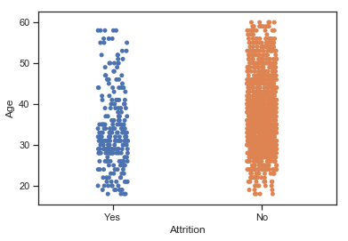

```python
sns.set(style='ticks')
ax = sns.stripplot(x='Attrition',y='Age', data=dataset)
```

### Plot Total working years using matplotlib plot function

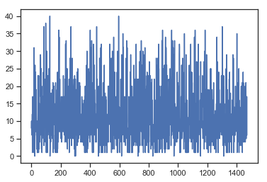

```python
import matplotlib.pyplot as plt
plt.plot(dataset['TotalWorkingYears'])
```